```python
# The code below is borrowed from Professor Zoran's Lecture 3 notebook
import numpy as np
import gensim
# Get the interactive Tools for Matplotlib
%matplotlib notebook
import matplotlib.pyplot as plt
plt.style.use('ggplot')
from sklearn.decomposition import PCA
from gensim.test.utils import datapath, get_tmpfile
from gensim.models import KeyedVectors
from gensim.scripts.glove2word2vec import glove2word2vec
```

# Problem 1.

Examine examples of analogic reasoning we demonstrated in Lecture 03. Jupyter notebook with those examples is uploaded in the folder for Lecture 03 of the class site. One such example is “what is to Russia, what Paris is to France?”. Those four words (Russia, France, Paris and Moscow) should present a polygon with four edges, perhaps a romb or rectangle. Create three more similar analogies and present them in the same PCA plane. We are just curious whether the geometric shapes of those examples are identical or very similar one to another. Please select analogies of very similar nature: countries vs. capitals, people vs food, etc. Do this using the 100-dimensional Glove vectors transformed into Word2Vec format. Use Gensim API. If you are familiar with Spacy or some other NLP API, please be free to use it.

```python
glove_file = datapath('/Users/ly/Desktop/Harvard Summer/glove/glove.6B.100d.txt')
word2vec_glove_file = get_tmpfile("glove.6B.100d.word2vec.txt")
glove2word2vec(glove_file, word2vec_glove_file)
model = KeyedVectors.load_word2vec_format(word2vec_glove_file)
```

```python
def display_pca_scatterplot(model, words=None, sample=0):
	if words == None:
		if sample > 0:
			words = np.random.choice(list(model.vocab.keys()), sample)
		else:
			words = [ word for word in model.vocab ]
	word_vectors = np.array([model[w] for w in words])
	twodim = PCA().fit_transform(word_vectors)[:,:2]
	plt.figure(figsize=(6,6))
	plt.scatter(twodim[:,0], twodim[:,1], edgecolors='k', c='r')
	for word, (x,y) in zip(words, twodim):
		plt.text(x+0.05, y+0.05, word)
	# Add connected lines to showoff the parallel relationship
	for i in range(0, len(twodim), 2):
		plt.plot(twodim[i:i+2,0],twodim[i:i+2,1],'r:')
```

### Analogy 1: Country - Philosopher

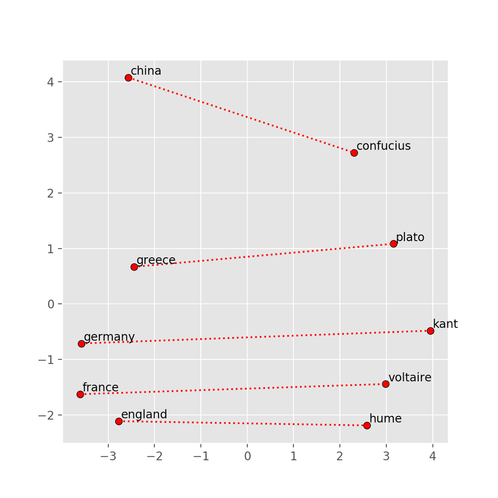

```python
display_pca_scatterplot(model,['france','voltaire',
                               'greece','plato',
                               'england','hume',
                               'china','confucius',
                               'germany','kant'])
```

### Comment:

The analogy is apparent, all the countries lie on the left side and all the philosophers lie on the right side. Moreover, the connected the line between the country and the corresponding philosopher appear to be approximitaly parallel. The parallel relationship is stronger for European countries but weaker for between China and European countries.

### Analogy 2: City - University

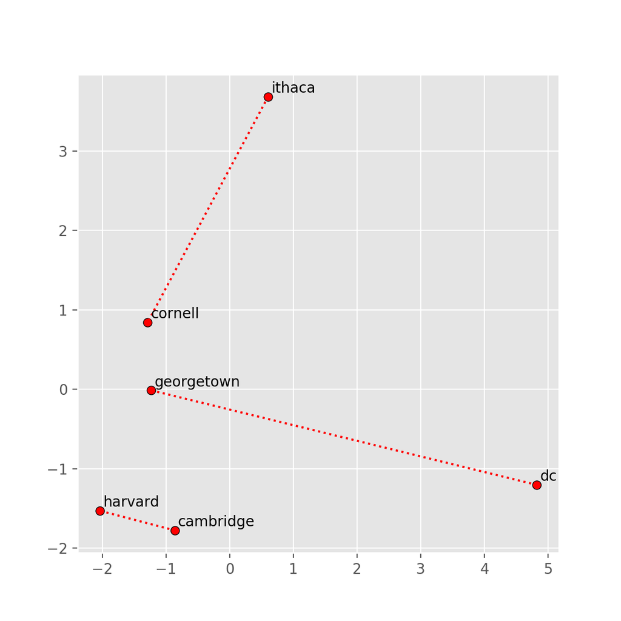

```python
display_pca_scatterplot(model,['cambridge','harvard',
                               'dc','georgetown',
                               'ithaca','cornell'])
```

### Comment:

The relationship holds for Georgetown University in DC and Harvard in Cambridge, but seems odd for Cornell in Ithaca. I also tested some city names with two words, such as "New York" and "Columbia", which turned out to be worse and was ignored.

### Analogy 3: NBA Team - Leading Player

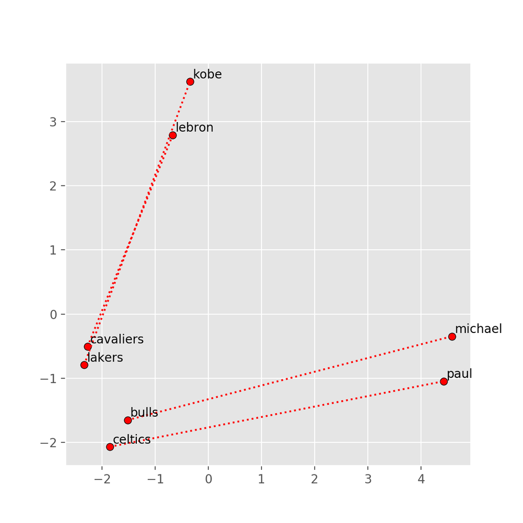

```python
display_pca_scatterplot(model,['lakers','kobe',
                               'celtics','paul',
                               'cavaliers','lebron',
                               'bulls','michael'
                               ])
```

### Comment:

The relationship approximately holds, the team names lie on the left while the player names on the right. Kobe Bryant is to Lakers as Lebron James to Cavaliers, which is so true! For Celtics, it's a bit off but Paul is not disambiguated. It could be Paul Pierce or Paul George. The same reason might explain Chicago Bulls and Michael Jordan. Besides, there must be a lot of texts/reports comparing Lebron James and Kobe Bryant, thus the close location of the two pair of points.

# Problem 2.

Repeat the above experiment with 300-dimensional Glove vectors transformed into Word2Vec format. We are curious whether the shape of above geometric shapes are preserved or modified in the higher dimensional space. Use PCA to make the projections.

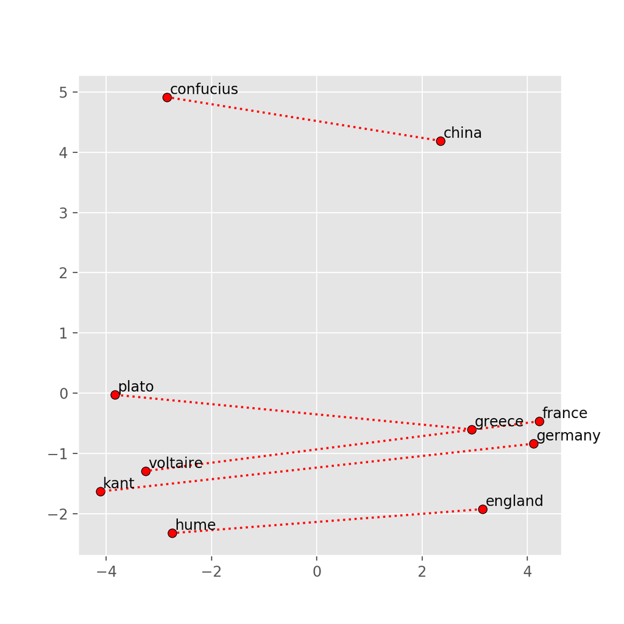

```python
display_pca_scatterplot(model_300,['france','voltaire',
                                   'greece','plato',
                                   'england','hume',
                                   'china','confucius',
                                   'germany','kant'])
```

### Comment:

The general shape or relative location of the lines holds, but for Greece - Plato, it becomes less parallel with the other European country - Philosophers, but more parallel with Chinese - Confucius, which actually makes sense. Becaues Plato and Confucius are philosophers a long time ago while those for the other European countries are more recent.

### Analogy 2: City - University

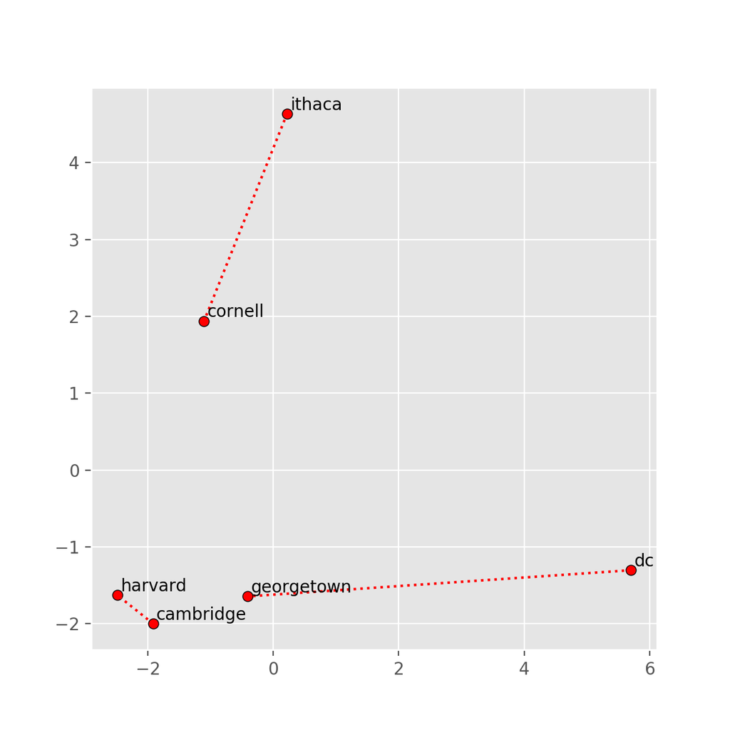

```python
display_pca_scatterplot(model_300,['cambridge','harvard',
                                   'dc','georgetown',
                                   'ithaca','cornell'])
```

### Comment:

The relationships become worse somehow.

### Analogy 3: NBA Team - Leading Player

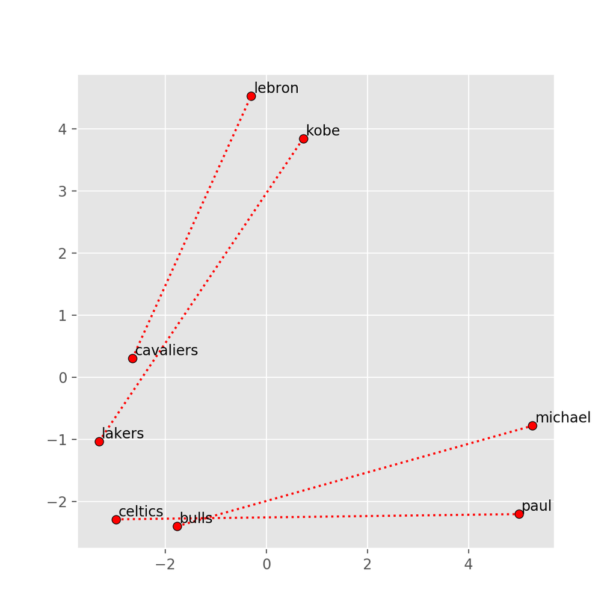

```python
display_pca_scatterplot(model_300,['lakers','kobe',
                                   'celtics','paul',
                                   'cavaliers','lebron',
                                   'bulls','michael'
                                   ])
```

### Comment:

The relationships become worse somehow. Lakers - Koby and Cavaliers - Lebron becomes more separate while Celtics - Paul becomes almost flat. Paul could potentially refer to more person in the high dimensional place.

# Problem 3.

Repeat the above experiment from problem 1 using Sci-kit Learn T-SNE projections, rather than PCA.

```python
from sklearn.manifold import TSNE
```

```python
# Adapt pca function to tsne
# Add a parameter random_state for easy tuning
def display_tsne_scatterplot(model,random_state, words=None, sample=0):
    if words == None:
        if sample > 0:
            words = np.random.choice(list(model.vocab.keys()), sample)
        else:
            words = [ word for word in model.vocab ]
    word_vectors = np.array([model[w] for w in words])
    tsne = TSNE(perplexity=30, n_components=2, init='random', n_iter=5000,
                method='exact',random_state = random_state)
    twodim = tsne.fit_transform(word_vectors[:, :2])
    #twodim = PCA().fit_transform(word_vectors)[:,:2]
    plt.figure(figsize=(6,6))
    plt.scatter(twodim[:,0], twodim[:,1], edgecolors='k', c='r')
    for word, (x,y) in zip(words, twodim):
        plt.text(x+0.05, y+0.05, word)
    # Add connected lines to showoff the parallel relationship
    for i in range(0, len(twodim), 2):
        plt.plot(twodim[i:i+2,0],twodim[i:i+2,1],'r:')
```

### Analogy 1: Country - Philosopher

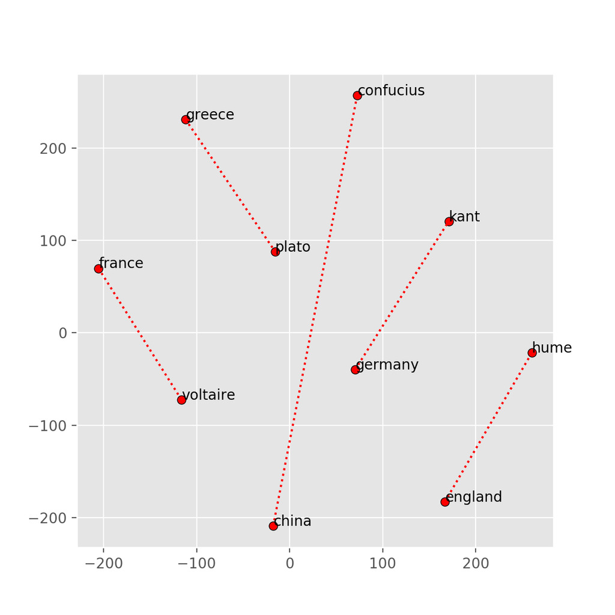

```python
display_tsne_scatterplot(model,10,['france','voltaire',
                               'greece','plato',
                               'england','hume',
                               'china','confucius',
                               'germany','kant'])
```

### Comment:

The relationship now looks weird, which could be due to random initialization. The chart looks somewhat symmetric with random state = 10.

### Analogy 2: City - University

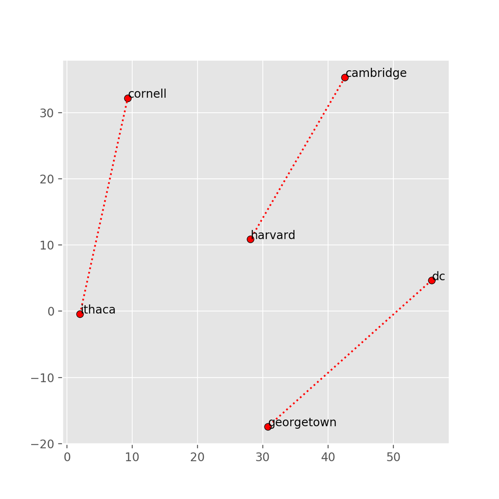

```python
display_tsne_scatterplot(model,1, ['cambridge','harvard',
                                   'dc','georgetown',
                                   'ithaca','cornell'])
```

### Comment:

The relationship almost holds. But Cornell-Ithaca should have reversed. Note that random state actually affects the result.

### Analogy 3: NBA Team - Leading Player

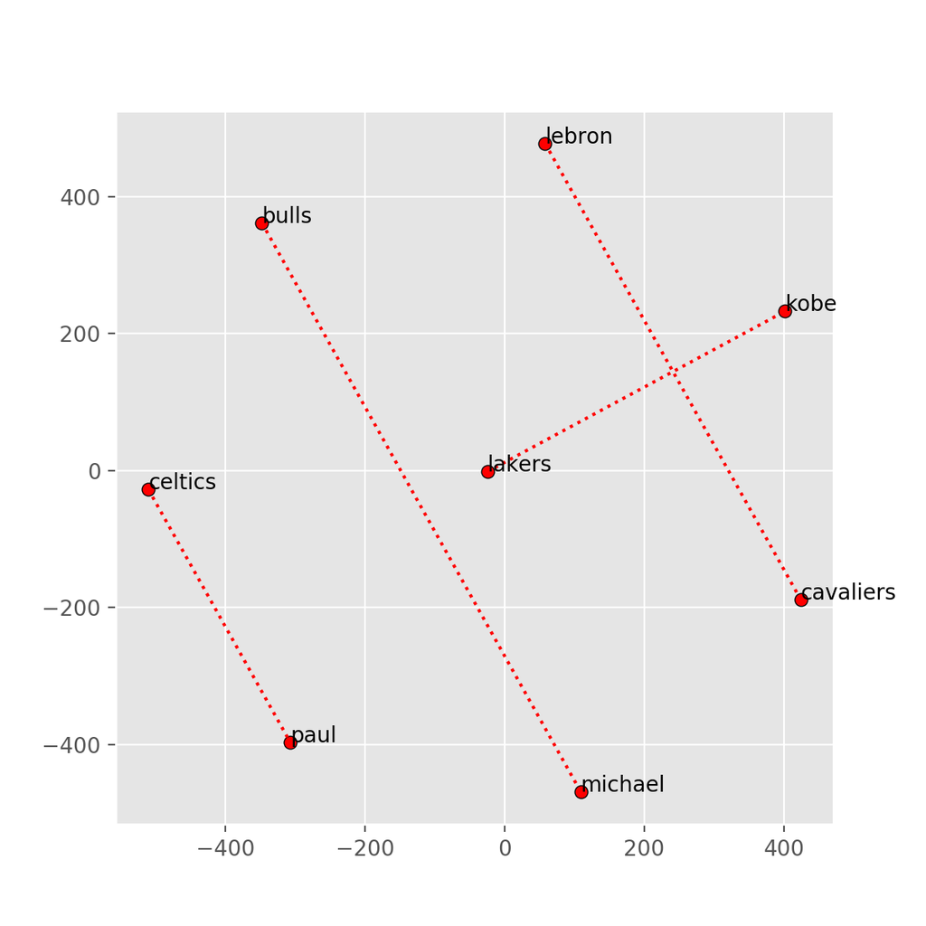

```python
display_tsne_scatterplot(model,102, ['lakers','kobe',
                                'celtics','paul',
                                'cavaliers','lebron',
                                'bulls','michael'
                                ])
```

### Comment:

The relationship appears different from before. Celtics - Paul and Bulls - Michael are parallel. Lebron - Cavaliers seems reversed while Kobe - Lakers crosses with Lebron - Cavaliers. Still, random state actually affects the result.

# Problem 4.

Try to use the simplest architecture we discussed in Lecture 4 with two Dense layers to create a de-noising autoencoder. Use the latent space of dimension 64. Report on your findings.

### 1) Create Noisy Data

```python
from keras.datasets import mnist
import numpy as np

(x_train, _), (x_test, _) = mnist.load_data()

x_train = x_train.astype('float32') / 255.
x_test = x_test.astype('float32') / 255.
x_train = x_train.reshape((len(x_train), np.prod(x_train.shape[1:])))
x_test = x_test.reshape((len(x_test), np.prod(x_test.shape[1:])))

noise_factor = 0.5
x_train_noisy = x_train + noise_factor * np.random.normal(loc=0.0, scale=1.0, size=x_train.shape)
x_test_noisy = x_test + noise_factor * np.random.normal(loc=0.0, scale=1.0, size=x_test.shape)

x_train_noisy = np.clip(x_train_noisy, 0., 1.)
x_test_noisy = np.clip(x_test_noisy, 0., 1.)
print("train.shape: ", x_train_noisy.shape)
print("test.shape: ", x_test_noisy.shape)
```

```
train.shape:  (60000, 784)
test.shape:  (10000, 784)
```

### 2） Visualize Noisy Data

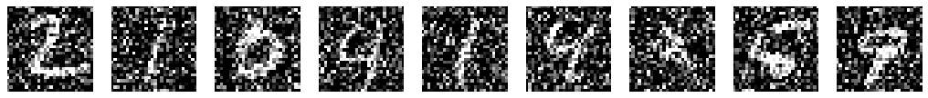

```python
# use Matplotlib
import matplotlib.pyplot as plt
%matplotlib inline

n = 10
plt.figure(figsize=(20, 2))
for i in range(1,n,1):
    ax = plt.subplot(1, n, i)
    plt.imshow(x_test_noisy[i].reshape(28, 28))
    plt.gray()
    ax.get_xaxis().set_visible(False)
    ax.get_yaxis().set_visible(False)
plt.show()
```

### 3） Create a 2-layer autoencoder

#### Autoencoder

```python
import keras
from keras.layers import Input, Dense
from keras.models import Model

# set encoding dimension as 64 64-D Latent Space
encoding_dim = 64  # assuming the input is 784 floats

# this is our input placeholder
input_img = Input(shape=(784,))
# add first layer
first_layer = Dense(encoding_dim, activation='relu')(input_img)
# "encoded" is the encoded representation of the input
encoded = Dense(encoding_dim, activation='relu')(first_layer)
# "decoded" is the lossy reconstruction of the input
decoded = Dense(784, activation='sigmoid')(encoded)

# this model maps an input to its reconstruction
autoencoder = Model(input_img, decoded)
```

#### Encoder

```python
# this model maps an input to its encoded representation
encoder = Model(input_img, encoded)
```

#### Decoder

```python
# create a placeholder for an encoded (32-dimensional) input
encoded_input = Input(shape=(encoding_dim,))
# retrieve the last layer of the autoencoder model
decoder_layer = autoencoder.layers[-1]
# create the decoder model
decoder = Model(encoded_input, decoder_layer(encoded_input))
```

#### Compile autoencoder

```python
autoencoder.compile(optimizer='adadelta', loss='binary_crossentropy')
```

```python
history = autoencoder.fit(x_train_noisy, x_train,
                            epochs=50,
                            batch_size=128,
                            shuffle=True,
                            validation_data=(x_test_noisy, x_test))
```

```
Train on 60000 samples, validate on 10000 samples
```

### Show training and validation loss change by epochs

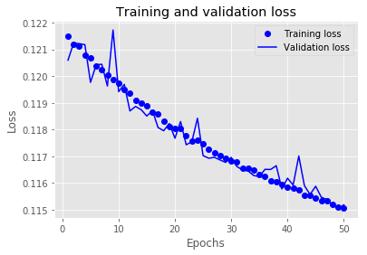

```python
import matplotlib.pyplot as plt
%matplotlib inline

loss = history.history['loss']
val_loss = history.history['val_loss']

epochs = range(1, len(loss) + 1)



# "bo" is for "blue dot"
plt.plot(epochs, loss, 'bo', label='Training loss')
# b is for "solid blue line"
plt.plot(epochs, val_loss, 'b', label='Validation loss')
plt.title('Training and validation loss')
plt.xlabel('Epochs')
plt.ylabel('Loss')
plt.legend()

plt.show()
```

### Comment:

Training loss decreases as we train more epochs while validation loss also shows a downward trend with occasionally fluctuation. Yet, if we notice the y axis scale, within 50 epochs, the training loss and the validation loss only decreases by around 0.007, so the model doesn't really improve much. But the loss is overall low at around 0.12.

### Show signal intensity and encodings

```
Signal intensity:  5.68109
```

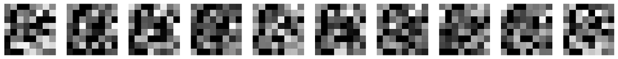

```python
# note that we take them from the *test* set
encoded_imgs = encoder.predict(x_test_noisy)
print("Signal intensity: ", encoded_imgs.mean())
n = 10  # how many digits we will display
plt.figure(figsize=(20, 4))
for i in range(n):
    # display codings as 4x8 array
    ax = plt.subplot(2, n, i + 1 + n)
    plt.imshow(encoded_imgs[i].reshape(8, 8))
    plt.gray()
    ax.get_xaxis().set_visible(False)
    ax.get_yaxis().set_visible(False)
plt.show()
```

### Comment:

As usual, it's hard to interpret the encodings.

### Show noisy and denoised images

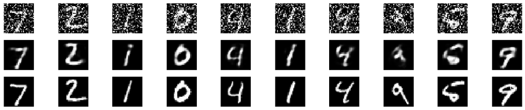

```python
decoded_imgs = autoencoder.predict(x_test_noisy)

n = 10  # how many digits we will display
plt.figure(figsize=(20, 4))
for i in range(n):
    # display original noisy digits
    ax = plt.subplot(3, n, i + 1)
    plt.imshow(x_test_noisy[i].reshape(28, 28))
    plt.gray()
    ax.get_xaxis().set_visible(False)
    ax.get_yaxis().set_visible(False)

    # display reconstruction
    ax = plt.subplot(3, n, i + 1 + n)
    plt.imshow(decoded_imgs[i].reshape(28, 28)) # decoded_img
    plt.gray()
    ax.get_xaxis().set_visible(False)
    ax.get_yaxis().set_visible(False)

    # display original digits
    ax = plt.subplot(3, n, i + 1 + 2*n)
    plt.imshow(x_test[i].reshape(28, 28))
    plt.gray()
    ax.get_xaxis().set_visible(False)
    ax.get_yaxis().set_visible(False)
plt.show()
```

Top row: noisy image  
Middle row:denoised image  
Bottom row: original clean image

### Comment:

The denoised image turn out to be pretty good.

# Problem 5.

Consider image denoising auto decoder described on slide 54 of the notes for Lecture 4. Make an experiment by reducing the number of filters (channels) contained in all Conv2D layers from 32 to 16. Compare results of autoencoders with 32 and 16 channels visually. Could you come up with a technique to compare the quality of denoising more accurately. In either case present the effect of removing noise from handwritten digits 3, 6, and 8.

### Reload, reshape data, add noise and clip

```python
from keras.datasets import mnist
import numpy as np

(x_train, y_train), (x_test, y_test) = mnist.load_data()

x_train = x_train.astype('float32') / 255.
x_test = x_test.astype('float32') / 255.
x_train = np.reshape(x_train, (len(x_train), 28, 28, 1))  # adapt this if using `channels_first` image data format
x_test = np.reshape(x_test, (len(x_test), 28, 28, 1))  # adapt this if using `channels_first` image data format

noise_factor = 0.1 # Only add a small fraction of noise
x_train_noisy = x_train + noise_factor * np.random.normal(loc=0.0, scale=1.0, size=x_train.shape)
x_test_noisy = x_test + noise_factor * np.random.normal(loc=0.0, scale=1.0, size=x_test.shape)

x_train_noisy = np.clip(x_train_noisy, 0., 1.)
x_test_noisy = np.clip(x_test_noisy, 0., 1.)
```

```python
from keras.layers import Input, Dense, Conv2D, MaxPooling2D, UpSampling2D
from keras.models import Model
from keras import backend as K

def build_autoencoder(dim):
    input_img = Input(shape=(28, 28, 1))  # adapt this if using `channels_first` image data format

    x = Conv2D(dim, (3, 3), activation='relu', padding='same')(input_img)
    x = MaxPooling2D((2, 2), padding='same')(x)
    x = Conv2D(dim, (3, 3), activation='relu', padding='same')(x)
    encoded = MaxPooling2D((2, 2), padding='same')(x)

    # at this point the representation is (7, 7, 32)

    x = Conv2D(dim, (3, 3), activation='relu', padding='same')(encoded)
    x = UpSampling2D((2, 2))(x)
    x = Conv2D(dim, (3, 3), activation='relu', padding='same')(x)
    x = UpSampling2D((2, 2))(x)
    decoded = Conv2D(1, (3, 3), activation='sigmoid', padding='same')(x)

    # Extract encoder
    encoder = Model(input_img, encoded)

    # Build autoencoder
    autoencoder = Model(input_img, decoded)
    autoencoder.compile(optimizer='adadelta', loss='binary_crossentropy')

    return autoencoder,encoder
```

```python
def fit_autoencoder(autoencoder, epochs):
    history = autoencoder.fit(x_train_noisy, x_train,
                    epochs=epochs,
                    batch_size=256,
                    shuffle=True,
                    validation_data=(x_test_noisy, x_test))
    return history
```

### Build 32D Autoencoder and Extract Encoder

```python
# Limit to 15 epochs considering the running time
autoencoder_32, encoder_32 = build_autoencoder(32)
```

### Fit 32D Autoencoder

```python
history_32 = fit_autoencoder(autoencoder_32, 15)
```

```
Train on 60000 samples, validate on 10000 samples
```

### Build 16D Autoencoder and Extract Encoder

```python
autoencoder_16,encoder_16 = build_autoencoder(16)
```

### Fit 16D Autoencoder

```python
history_16 = fit_autoencoder(autoencoder_16, 15)
```

```
Train on 60000 samples, validate on 10000 samples
```

### Comment:

```python
# Subset indexes for digits 3,6,8
y_test_3_inx = list(np.where(y_test == 3)[0])
y_test_6_inx = list(np.where(y_test == 6)[0])
y_test_8_inx = list(np.where(y_test == 8)[0])
```

```python
plt_368_inx = y_test_3_inx[:3] + y_test_6_inx[:3] + y_test_8_inx[:3]
print("Plot two 3-digit, two 6-digit, two 8-digit at index:", plt_368_inx)
```

[output not shown]

```python
# Get decoded images
decoded_imgs_32 = autoencoder_32.predict(x_test_noisy)
decoded_imgs_32_noiseless = autoencoder_32.predict(x_test)
decoded_imgs_16 = autoencoder_16.predict(x_test_noisy)
decoded_imgs_16_noiseless = autoencoder_16.predict(x_test)
```

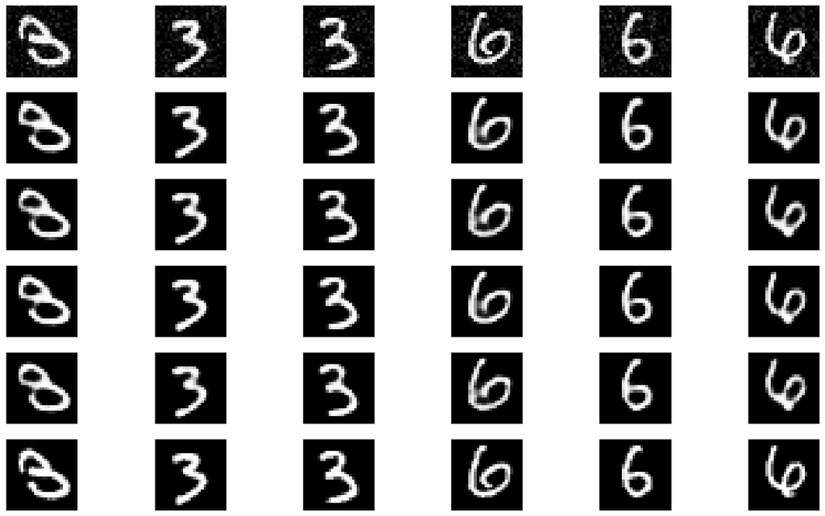

```python
n = 6 # how many digits we will display
plt.figure(figsize=(20, 12))
for i in range(6):
    # display original noisy images
    ax = plt.subplot(6, n, i + 1)
    plt.imshow(x_test_noisy[plt_368_inx[i]].reshape(28, 28))
    plt.gray()
    ax.get_xaxis().set_visible(False)
    ax.get_yaxis().set_visible(False)

    # display reconstruction of 32D
    ax = plt.subplot(6, n, i + 1 + n)
    plt.imshow(decoded_imgs_32[plt_368_inx[i]].reshape(28, 28))
    plt.gray()
    ax.get_xaxis().set_visible(False)
    ax.get_yaxis().set_visible(False)

    # display reconstruction of 16D
    ax = plt.subplot(6, n, i + 1 + 2*n)
    plt.imshow(decoded_imgs_16[plt_368_inx[i]].reshape(28, 28))
    plt.gray()
    ax.get_xaxis().set_visible(False)
    ax.get_yaxis().set_visible(False)

    # display reconstruction of 32D on images without noise
    ax = plt.subplot(6, n, i + 1 + 3*n)
    plt.imshow(decoded_imgs_32_noiseless[plt_368_inx[i]].reshape(28, 28))
    plt.gray()
    ax.get_xaxis().set_visible(False)
    ax.get_yaxis().set_visible(False)

    # display reconstruction of 16D on images without noise
    ax = plt.subplot(6, n, i + 1 + 4*n)
    plt.imshow(decoded_imgs_16_noiseless[plt_368_inx[i]].reshape(28, 28))
    plt.gray()
    ax.get_xaxis().set_visible(False)
    ax.get_yaxis().set_visible(False)

    # display original digits
    ax = plt.subplot(6, n, i + 1 + 5*n)
    plt.imshow(x_test[plt_368_inx[i]].reshape(28, 28))
    plt.gray()
    ax.get_xaxis().set_visible(False)
    ax.get_yaxis().set_visible(False)

plt.show()
```

1st row: noisy image  
2nd row: denoised image of 32D CNN  
3rd row: denoised image of 16D CNN  
4th row: reconstructed image of 32D CNN on clean images  
5th row: reconstructed image of 16D CNN on clean images  
6th row: original clean image

### Quantitatively compare the quality of denoising with signal intensity

```python
# Get average signal intensity by digits and encoder
def getDigitSignalIntensity(encoder,digit,noise):
    indices = list(np.where(y_test == digit)[0])
    if noise == True:
        encoded_imgs = encoder.predict(np.take(x_test_noisy, indices, axis = 0))
    else:
        encoded_imgs = encoder.predict(np.take(x_test, indices, axis = 0))
    return encoded_imgs.mean()
```

```python
import pandas as pd
# Create a data frame to showcase the results
digits = list(range(10))
digit_signal_16 = {digit:getDigitSignalIntensity(encoder_16,digit,True) for digit in digits}
digit_signal_32 = {digit:getDigitSignalIntensity(encoder_32,digit,True) for digit in digits}
digit_signal_16_clean = {digit:getDigitSignalIntensity(encoder_16,digit,False) for digit in digits}
digit_signal_32_clean = {digit:getDigitSignalIntensity(encoder_32,digit,False) for digit in digits}
```

```python
digit_signal_df = pd.DataFrame([digit_signal_16,digit_signal_32,
                                digit_signal_16_clean,digit_signal_32_clean],
                                index = ['16D-CNN-Noisy','32D-CNN-Noisy',
                                         '16D-CNN-Clean','32D-CNN-Clean'])
digit_signal_df
```

|  | 0 | 1 | 2 | 3 | 4 | 5 | 6 | 7 | 8 | 9 |
| --- | --- | --- | --- | --- | --- | --- | --- | --- | --- | --- |
| 16D-CNN-Noisy | 0.525209 | 0.348249 | 0.491905 | 0.485120 | 0.442398 | 0.468604 | 0.471544 | 0.426098 | 0.491441 | 0.442848 |
| 32D-CNN-Noisy | 0.396922 | 0.299583 | 0.380786 | 0.377439 | 0.352754 | 0.368156 | 0.367764 | 0.343289 | 0.379044 | 0.352243 |
| 16D-CNN-Clean | 0.529994 | 0.340455 | 0.494217 | 0.487181 | 0.441563 | 0.469346 | 0.472268 | 0.423497 | 0.493262 | 0.441237 |
| 32D-CNN-Clean | 0.404399 | 0.293407 | 0.386574 | 0.383122 | 0.355082 | 0.372437 | 0.370913 | 0.343362 | 0.383416 | 0.353019 |